# README

José Antonio García Ramirez

January 12, 2018

[figure not shown]

For the beautiful visualizations I recommend checking the file *README.HTML*

## Package installation

```r
devtools::install_github("fou-foo/FouR")
```

## INTRODUCTION

The FouR package is created (in its first release) to visualize NOAA earthquake data. It processes data from [NOAA database](https://www.ngdc.noaa.gov/nndc/struts/form?t=101650&s=1&d=1) and visualizes them using `ggplot2` and `leaflet` packages.

This vignette two process: - Cleaning - Two different visualizations (over time - like [Doctor Who](https://en.wikipedia.org/wiki/Doctor_Who) would see it - and country)

## DATA

About the NOAA earthquake data. the data come can be obtained from [NOAA Significant Earthquake Database](https://www.ngdc.noaa.gov/nndc/struts/form?t=101650&s=1&d=1).

It is evident that the data set has numerous columns with null or missing values, although a future and interesting work for this package would be to apply data imputation techniques to the dataset . For the above you can use the function `eq_clean_data()` and `eq_location_clean()`

```r
head(data, 3)
```

```
#>     I_D FLAG_TSUNAMI YEAR MONTH DAY HOUR MINUTE SECOND FOCAL_DEPTH
#> 1 10265         <NA>   37     4   9   NA     NA   <NA>          NA
#> 2  7896         <NA>   46    10  23   NA     NA   <NA>          NA
#> 3    58         <NA>   79     8  24   NA     NA   <NA>          NA
#>   EQ_PRIMARY EQ_MAG_MW EQ_MAG_MS EQ_MAG_MB EQ_MAG_ML EQ_MAG_MFA EQ_MAG_UNK
#> 1         NA        NA        NA      <NA>        NA       <NA>         NA
#> 2        6.5        NA       6.5      <NA>        NA       <NA>         NA
#> 3         NA        NA        NA      <NA>        NA       <NA>         NA
#>   INTENSITY COUNTRY STATE                    LOCATION_NAME LATITUDE
#> 1        NA  TURKEY  <NA>       TURKEY:  ANTAKYA (ANTIOCH)   36.100
#> 2         8   CHINA  <NA> CHINA:  HENAN PROVINCE:  NANYANG   33.000
#> 3        10   ITALY  <NA>          ITALY:  NAPLES (NAPOLI)   40.821
#>   LONGITUDE REGION_CODE DEATHS DEATHS_DESCRIPTION MISSING
#> 1    36.100         140     NA                  3    <NA>
#> 2   112.500          30     NA                  2    <NA>
```

[output cut: 37 more lines]

## Package content

- `fecha()`
- `eq_clean_data()`
- `eq_location_clean()`
- `theme_timeline()`
- `GeomTimeline()`
- `GeomTimelineLabel()`
- `theme_timeline()`
- `geom_timeline()`
- `geom_timeline_label()`
- `eq_map()`

## Data cleaning

It is evident that the data set has numerous columns with null or missing values, although a future and interesting work for this package would be to apply data imputation techniques to the dataset . For the above you can use the function `eq_clean_data()` and `eq_location_clean()`

## Visualization of earthquakes by time and place :

1. [Doctor-Who](https://en.wikipedia.org/wiki/Doctor_Who)‘s view ( or style1), *all the time* and *all the countries* at once. You can visualize earthquakes in all dataset’s time variable *YEAR* without filter by the columns *COUNTRY* and *YEAR* and using the package *ggplot* and the recently implemented `geom_`, `geom_timeline` and `geom_timeline_label`. (you must pay attention with the column so that the visualization is of a suitable size and not empty, as in every ggplot´s function, one must have congruent with the variables’ name of the dataset and the parameters of `ggplot2::aes` function.)[^1]

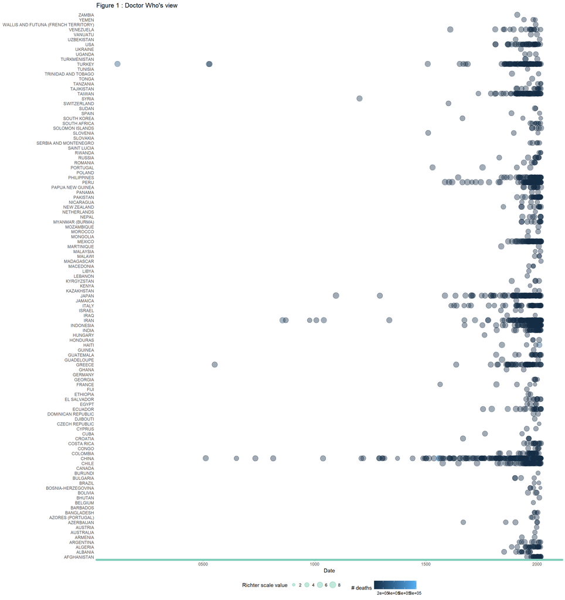

```r
data %>%
filter( DEATHS>0) %>%
     ggplot(aes(x = Date,
                y = COUNTRY,
                color = DEATHS,
                size = as.numeric(EQ_PRIMARY)
     )) +
     geom_timeline() +
     #geom_timeline_label(aes(label = LOCATION_NAME)) +
     theme_timeline() +
     labs(size = "Richter scale value", color = "# deaths",
          title = "Figure 1 : Doctor Who's view")
```

2. No-Doctor-Who’s (style2), not all the time neither all the countries at once. You can visualize earthquakes in a single country after filter by the column `COUNTRY` or many others, (you must pay attention with the columns of *YEAR* and *DEATHS* so that the visualization is of a suitable size and not empty, as in every ggplot´s function, one must have congruent with the variables’ name of the dataset and the parameters of `ggplot2::aes` function.)

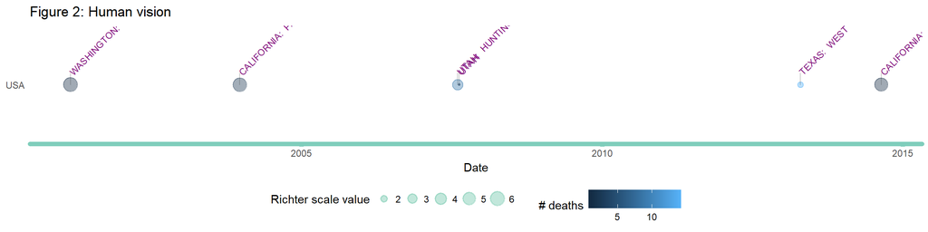

```r
data %>%
filter(COUNTRY %in% c("USA"), 2020 > YEAR,  YEAR > 2000, DEATHS>0) %>%
     ggplot(aes(x = Date,
                y = COUNTRY,
                color = DEATHS,
                size = as.numeric(EQ_PRIMARY)
     )) +
     geom_timeline() +
     geom_timeline_label(aes(label = LOCATION_NAME)) +
     theme_timeline() +
     labs(size = "Richter scale value", color = "# deaths",
     title = "Figure 2: Human vision")
```

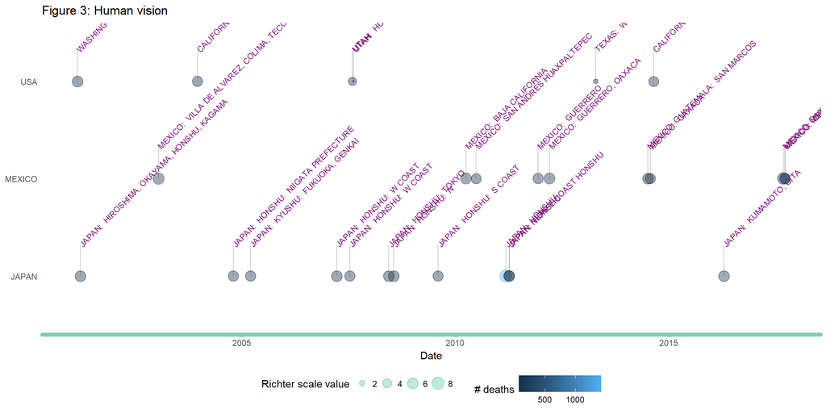

```r
data %>%
filter(COUNTRY %in% c("USA", "MEXICO", "JAPAN"), 2020 > YEAR,  YEAR > 2000, DEATHS>0) %>%
     ggplot(aes(x = Date,
                y = COUNTRY,
                color = DEATHS,
                size = as.numeric(EQ_PRIMARY)
     )) +
     geom_timeline() +
     geom_timeline_label(aes(label = LOCATION_NAME)) +
     theme_timeline() +
     labs(size = "Richter scale value", color = "# deaths",
     title = "Figure 3: Human vision")
```

# Visualize earthquakes on a pretty map

Using the `leaflet` package it is very easy to make beautiful interactive maps using the function `eq_map()`.There are two options to use this function one without using the function `eq_create_label()` from where we get the following map:

```r
data %>%
   dplyr::filter(COUNTRY == "MEXICO" & lubridate::year(Date) >= 2000) %>%
  eq_map(annot_col = "Date")
```

[interactive chart not shown]

And the other one using it

```r
data %>%
 dplyr::filter(COUNTRY == "MEXICO" & lubridate::year(Date) >= 2000) %>%
  dplyr::mutate(popup_text = eq_create_label(.)) %>%
  eq_map(annot_col = "popup_text")
```

[interactive chart not shown]

[^1]: Thanks to my [brother](https://www.facebook.com/lucaridavidmisticmaster) and my friend [Claudia](https://www.facebook.com/Ayla.occord?pnref=friends.search) for the idea about figure 1.